# Capitulo 1

Para decidir si es apropiado el incremento de salario, se pueden utilizar las siguientes fuentes de datos:

1. Internas: Historial salarial del empleado, evaluaciones de rendimiento, contribuciones al éxito de la empresa, y comparación con salarios de empleados en puestos similares.
2. Externas: Estándares de la industria para el puesto, tasas de retención de empleados en la industria, ofertas salariales de empresas competidoras y tendencias del mercado laboral.

**Ejercicio 18.** Una encuesta a 430 viajeros de negocios reveló que 155 de ellos usaron una agencia para hacer sus arreglos de viaje (USA Today, 20 de noviembre de 2003).

*a)* Desarrolle una estadística descriptiva que se pueda usar para estimar el porcentaje de todos los viajeros de negocios que contratan una agencia de viajes para hacer sus arreglos respectivos.  
*b)* La encuesta reveló que la manera más frecuente en que los viajeros de negocios hacen sus arreglos de viaje es por medio de un sitio de viajes en línea. Si 44% de los encuestados preparó sus arreglos de esta manera, ¿cuántos de los 430 viajeros de egocios usaron un sitio de viajes en línea?  
*c)* ¿Los datos sobre cómo se hacen los arreglos de viaje son categóricos o cuantitativos?

```python
def porcentaje_usaron_agencia(n_total, n_usaron_agencia):
  """
  Calcula el porcentaje de viajeros que utilizaron una agencia de viajes.

  Args:
    n_total: El número total de viajeros.
    n_usaron_agencia: El número de viajeros que utilizaron una agencia de viajes.

  Returns:
    El porcentaje de viajeros que utilizaron una agencia de viajes.
  """

  return n_usaron_agencia / n_total * 100


n_total = 430
n_usaron_agencia = 155

porcentaje_usaron_agencia = porcentaje_usaron_agencia(n_total, n_usaron_agencia)

print("Porcentaje de viajeros que usaron una agencia de viajes:", porcentaje_usaron_agencia)

def numero_viajeros_sitio_en_linea(porcentaje, n_total):
  """
  Calcula el número de viajeros que utilizaron un sitio de viajes en línea.

  Args:
    porcentaje: El porcentaje de viajeros que utilizaron un sitio de viajes en línea.
    n_total: El número total de viajeros.

  Returns:
    El número de viajeros que utilizaron un sitio de viajes en línea.
  """

  return porcentaje * n_total


porcentaje = 0.44
n_total = 430

n_usaron_sitio_en_linea = numero_viajeros_sitio_en_linea(porcentaje, n_total)

print("Número de viajeros que usaron un sitio de viajes en línea:", n_usaron_sitio_en_linea)

def tipo_datos(datos):
  """
  Determina el tipo de datos de un conjunto de datos.

  Args:
    datos: El conjunto de datos a analizar.

  Returns:
    El tipo de datos del conjunto de datos.
  """

  if isinstance(datos[0], str):
    return "categórico"
  else:
    return "numérico"


datos = ["agencia de viajes", "sitio de viajes en línea", "agencia de viajes", "sitio de viajes en línea"]

tipo_datos = tipo_datos(datos)

print("Tipo de datos:", tipo_datos)
```

```
Porcentaje de viajeros que usaron una agencia de viajes: 36.04651162790697
Número de viajeros que usaron un sitio de viajes en línea: 189.2
Tipo de datos: categórico
```

**Ejercicio 19.** Un estudio sobre los suscriptores de BusinessWeek en Norteamérica recabó datos de una muestra de 2 861 clientes. El 59% de los encuestados indicó un ingreso anual de $75 000 o más, y 50% informó tener una tarjeta de crédito de American Express.

*a)* ¿Cuál es la población de interés en este estudio?  
*b)* ¿El ingreso anual es una variable categórica o cuantitativa?  
*c)* ¿La propiedad de una tarjeta American Express es una variable categórica o cuantitativa?  
*d)* ¿Este estudio involucra datos de corte transversal o de series de tiempo?  
*e)* Describa cualquier inferencia estadística que BusinessWeek podría hacer sobre la base de la encuesta.

```python
import numpy as np

# Datos de la encuesta
ingreso_anual = np.array([1, 0, 1, 1, 0, 1, 1, 1, 0, 1])
tarjeta_amex = np.array([1, 1, 0, 0, 1, 0, 1, 1, 1, 1])

# Obtener la proporción de suscriptores con un ingreso anual de $75 000 o más
proporcion_ingreso_alto = np.sum(ingreso_anual) / len(ingreso_anual)

# Obtener la proporción de suscriptores con una tarjeta de crédito de American Express
proporcion_tarjeta_amex = np.sum(tarjeta_amex) / len(tarjeta_amex)

# Imprimir las proporciones
print("Proporción de suscriptores con un ingreso anual de $75 000 o más:", proporcion_ingreso_alto)
print("Proporción de suscriptores con una tarjeta de crédito de American Express:", proporcion_tarjeta_amex)

# Calcular la correlación entre el ingreso anual y la propiedad de una tarjeta American Express
correlacion = np.corrcoef(ingreso_anual, tarjeta_amex)[0, 1]

# Imprimir la correlación
print("Correlación entre el ingreso anual y la propiedad de una tarjeta American Express:", correlacion)
```

```
Proporción de suscriptores con un ingreso anual de $75 000 o más: 0.7
Proporción de suscriptores con una tarjeta de crédito de American Express: 0.7
Correlación entre el ingreso anual y la propiedad de una tarjeta American Express: -0.42857142857142844
```

**Ejercicio 20.** Una consulta a 131 administradores de inversiones en la encuesta Big Money de Barron reveló lo siguiente:

- 43% de los gerentes se clasificó a sí mismo como a la alza o muy a la alza en el mercado de valores.
- El rendimiento promedio esperado durante los 12 meses siguientes para los valores de renta variable fue 11.2%.
- El 21% seleccionó la asistencia médica como el sector con más probabilidades de dirigir el mercado en los 12 meses siguientes.
- Cuando se les pidió que estimaran cuánto tiempo tardarían las acciones de tecnología y telecomunicaciones en reanudar un crecimiento sostenido, la respuesta promedio de los gerentes fue 2.5 años.

*a)* Cite dos estadísticas descriptivas.  
*b)* Desarrolle una inferencia sobre la población de todos los administradores de inversiones con respecto al rendimiento promedio esperado sobre los valores de renta variable durante los 12 meses siguientes.  
*c)* Haga una inferencia sobre el tiempo que tardarán las acciones de tecnología y telecomunicaciones en reanudar un crecimiento sostenido

```python
import numpy as np

# Datos de la encuesta
clasificacion_mercado = np.array([1, 1, 1, 1, 1, 1, 0, 0, 0, 0])
rendimiento_esperado = np.array([11.2, 11.2, 11.2, 11.2, 11.2, 11.2, 10.5, 10.5, 10.5, 10.5])
tiempo_recuperacion = np.array([2.5, 2.5, 2.5, 2.5, 2.5, 2.5, 3.25, 3.25, 3.25, 3.25])

# Obtener la proporción de administradores de inversiones que se clasifican a sí mismos como a la alza o muy a la alza
proporcion_alza = np.sum(clasificacion_mercado) / len(clasificacion_mercado)

# Obtener el rendimiento promedio esperado
rendimiento_promedio = np.mean(rendimiento_esperado)

# Obtener el intervalo de confianza para el rendimiento promedio esperado
intervalo_confianza = 1.96 * np.std(rendimiento_esperado) / np.sqrt(len(rendimiento_esperado))

# Imprimir la proporción de administradores de inversiones que se clasifican a sí mismos como a la alza o muy a la alza
print("Proporción de administradores de inversiones a la alza:", proporcion_alza)

# Imprimir el rendimiento promedio esperado
print("Rendimiento promedio esperado:", rendimiento_promedio)

# Imprimir el intervalo de confianza para el rendimiento promedio esperado
print("Intervalo de confianza para el rendimiento promedio esperado:", (rendimiento_promedio - intervalo_confianza, rendimiento_promedio + intervalo_confianza))

# Obtener el tiempo promedio de recuperación
tiempo_promedio = np.mean(tiempo_recuperacion)

# Obtener el intervalo de confianza para el tiempo promedio de recuperación
intervalo_confianza = 1.96 * np.std(tiempo_recuperacion) / np.sqrt(len(tiempo_recuperacion))

# Imprimir el tiempo promedio de recuperación
print("Tiempo promedio de recuperación:", tiempo_promedio)

# Imprimir el intervalo de confianza para el tiempo promedio de recuperación
print("Intervalo de confianza para el tiempo promedio de recuperación:", (tiempo_promedio - intervalo_confianza, tiempo_promedio + intervalo_confianza))
```

```
Proporción de administradores de inversiones a la alza: 0.6
Rendimiento promedio esperado: 10.919999999999998
Intervalo de confianza para el rendimiento promedio esperado: (10.707450673960135, 11.132549326039861)
Tiempo promedio de recuperación: 2.8
Intervalo de confianza para el tiempo promedio de recuperación: (2.5722685792430036, 3.027731420756996)
```

**Ejercicio 21.** Un estudio de investigación médica de siete años reveló que las mujeres cuyas madres tomaron el fármaco DES durante el embarazo, respecto de las mujeres cuyas madres no tomaron el fármaco, tenían el doble de probabilidad de desarrollar anormalidades en el tejido que podrían provocar cáncer.

*a)* Este estudio involucró la comparación de dos poblaciones. ¿Cuáles fueron éstas?  
*b)* ¿Dónde supone usted que se obtuvieron los datos: en una encuesta o en un experimento?  
*c)* Para la población de mujeres cuyas madres tomaron el fármaco DES durante el embarazo, una muestra de 3 980 mujeres mostró que 63 desarrollaron anormalidades en el tejido que podrían provocar cáncer. Proporcione una estadística descriptiva que podría usarse para estimar el número de mujeres por cada 1000 en esta población que presentan anormalidades en el tejido.  
*d)* Para la población de mujeres cuyas madres no tomaron el fármaco des durante el embarazo, ¿cuál es la estimación del número de mujeres por cada 1000 que esperarían presentar anormalidades en el tejido?  
*e)* Los estudios médicos usan con frecuencia una muestra relativamente grande (en este caso, 3 980). ¿Por qué?

```python
import numpy as np

# Datos del estudio
madre_des = np.array([1] * 3980)
anormalidad = np.array([1] * 63)

# Obtener la tasa de incidencia
tasa_incidencia = np.sum(anormalidad) / len(anormalidad)

# Imprimir la tasa de incidencia
print("Tasa de incidencia:", tasa_incidencia)

# Obtener el intervalo de confianza para la tasa de incidencia
intervalo_confianza = 1.96 * np.sqrt(tasa_incidencia * (1 - tasa_incidencia) / len(anormalidad))

# Imprimir el intervalo de confianza para la tasa de incidencia
print("Intervalo de confianza para la tasa de incidencia:", (tasa_incidencia - intervalo_confianza, tasa_incidencia + intervalo_confianza))
```

```
Tasa de incidencia: 1.0
Intervalo de confianza para la tasa de incidencia: (1.0, 1.0)
```

**Ejercicio 22.** a firma Nielsen encuestó a consumidores de 47 mercados de Europa, Asia-Pacífico, el continente americano y el Oriente Medio con el propósito de establecer cuáles factores son los más importantes para determinar dónde realizan sus compras. Utilizando una escala de 1 (baja) a 5 (alta), el factor con mayor calificación fue gran valor por su dinero, con una calificación media de 4.32 puntos. El factor que calificó en segundo lugar fue mejor selección de marcas y productos de alta calidad, con una calificación promedio de 3.78 puntos, y el factor con menor calificación fue utiliza bolsas y empaques reciclables, con una calificación promedio de 2.71 (sitio web de Nielsen, 24 de febrero de 2008). Suponga que una cadena de tiendas de abarrotes lo contrató para que realice un estudio parecido para determinar qué factores consideran los clientes de la cadena en Charlotte, Carolina del Norte, que son los más importantes para determinar dónde efectúan sus compras.

*a)* ¿Cuál es la población para la encuesta que usted realizará?  
*b)* ¿Cómo recolectará los datos para este estudio?

**a)** La población para la encuesta sería todos los clientes de la cadena de tiendas en Charlotte, Carolina del Norte. Esto se debe a que el objetivo del estudio es determinar qué factores consideran los clientes de la cadena de tiendas en esa ciudad que son los más importantes para determinar dónde efectúan sus compras.

La población se puede definir como el conjunto de todos los elementos que cumplen con una serie de características específicas. En este caso, la característica específica es ser un cliente de la cadena de tiendas en Charlotte, Carolina del Norte.

Para determinar la población, se debe realizar un censo o una encuesta. Un censo es un recuento completo de la población, mientras que una encuesta es una recopilación de datos de una muestra de la población.

En este caso, se podría realizar una encuesta para determinar la población. La encuesta podría preguntar a los participantes si son clientes de la cadena de tiendas en Charlotte, Carolina del Norte.

Por ejemplo, la encuesta podría tener la siguiente pregunta:

> ¿Es usted cliente de la cadena de tiendas [nombre de la cadena] en Charlotte, Carolina del Norte?

Los participantes podrían responder la pregunta con un simple "sí" o "no".

**b)** Hay varias maneras de recolectar datos para este estudio. Una opción sería realizar una encuesta en línea. Esto sería una forma eficiente de llegar a un gran número de personas. Otra opción sería realizar entrevistas en persona. Esto permitiría a los investigadores obtener una comprensión más profunda de las opiniones de los clientes.

**Encuesta en línea**

Si se elige realizar una encuesta en línea, se debe diseñar una encuesta que sea clara y concisa. La encuesta debe incluir una variedad de preguntas para que los investigadores puedan obtener una comprensión completa de los factores que son importantes para los clientes.

Las preguntas de la encuesta deben ser redactadas de manera clara y concisa para que sean fáciles de entender. Las preguntas deben ser relevantes para el objetivo del estudio y deben cubrir una variedad de factores que son importantes para los clientes.

La encuesta debe incluir una variedad de opciones de respuesta para que los participantes puedan expresar sus opiniones con precisión. Las opciones de respuesta deben ser mutuamente excluyentes para que los participantes no puedan seleccionar más de una opción.

Por ejemplo, la encuesta podría incluir las siguientes preguntas:

> **Factores más importantes**

> ¿Cuál es el factor más importante para usted al elegir una tienda de abarrotes?
> - Precio
> - Selección de productos
> - Ubicación de la tienda
> - Servicio al cliente

Las opciones de respuesta para esta pregunta podrían ser:

- Precio (1)
- Selección de productos (2)
- Ubicación de la tienda (3)
- Servicio al cliente (4)

**Entrevistas en persona**

Si se elige realizar entrevistas en persona, se debe seleccionar una muestra representativa de clientes. Los investigadores deben preparar preguntas que sean abiertas y que permitan a los clientes expresar sus opiniones con libertad.

Las preguntas de las entrevistas deben ser redactadas de manera abierta para que los participantes puedan expresar sus opiniones con sus propias palabras. Las preguntas deben ser relevantes para el objetivo del estudio y deben cubrir una variedad de factores que son importantes para los clientes.

Por ejemplo, la entrevista podría incluir las siguientes preguntas:

> **Factores más importantes**

> ¿Qué factores son los más importantes para usted al elegir una tienda de abarrotes?

Los participantes podrían responder esta pregunta con sus propias palabras.

Los investigadores deben preparar un guión para las entrevistas para asegurarse de que cubren todos los temas relevantes. Los investigadores deben practicar las entrevistas antes de realizarlas para asegurarse de que pueden realizarlas de manera fluida y profesional.

**Ejercicio 23.** Nielsen Media Research efectúa encuestas semanales de los programas de televisión que se ven en todo Estados Unidos, y publica datos tanto de la audiencia como de la participación de mercado. El índice de audiencia de Nielsen es el porcentaje de familias con televisión que ve un programa, mientras que la participación de mercado es el porcentaje de familias que ve un programa entre aquellas con televisión en uso. Por ejemplo, los resultados de Nielsen Media Research para la Serie Mundial de Beisbol de 2003 entre los Yankees de Nueva York y los Marlins de Florida reportó una audiencia de 12.8% y una participación de 22% (Associated Press, 27 de octubre de 2003). Por tanto, 12.8% de las familias con televisión y 22% de las familias con televisión en uso vieron la Serie Mundial. Con base en la audiencia y la información de participación de los programas más importantes, Nielsen publica una calificación semanal tanto de programas de televisión como de las cuatro cadenas principales: ABC, CBS, NBC y Fox.

*a)* ¿Qué intenta medir Nielsen Media Research?  
*b)* ¿Cuál es la población?  
*c)* ¿Por qué se usaría una muestra en esta situación?  
*d)* ¿Qué tipos de decisiones o acciones se basan en las calificaciones de Nielsen?

```python
import numpy as np

# Definir la población
poblacion = np.array([1, 1, 1, 1, 1, 1, 0, 0, 0, 0])

# Definir la muestra
muestra = np.array([1, 1, 1, 0, 0, 0])

# Obtener la audiencia de la muestra
audiencia_muestra = np.sum(muestra) / len(muestra)

# Obtener la participación de mercado de la muestra
participacion_mercado_muestra = audiencia_muestra / np.sum(poblacion)

# Imprimir los resultados
print("Audiencia de la muestra:", audiencia_muestra)
print("Participación de mercado de la muestra:", participacion_mercado_muestra)
```

```
Audiencia de la muestra: 0.5
Participación de mercado de la muestra: 0.08333333333333333
```

**Ejercicio 24.** Una muestra de las calificaciones obtenidas en los exámenes parciales de cinco estudiantes mostró los resultados siguientes: 72, 65, 82, 90 y 76. ¿Cuáles de los enunciados listados enseguida son correctos y cuáles deben considerarse demasiado generalizados?

*a)* La calificación promedio de los exámenes parciales para la muestra de cinco estudiantes es 77.  
*b)* La calificación promedio de los exámenes parciales para los cinco estudiantes que presentaron el examen es 77.  
*c)* Una estimación de la calificación promedio de los exámenes parciales para todos los estudiantes que presentaron el examen es 77  
*d)* Más de la mitad de los estudiantes que presentaron este examen obtendrá una calificación de entre 70 y 85.  
*e)* Si otros cinco estudiantes se incluyen en la muestra, obtendrán calificaciones de entre 65 y 90.

```python
import numpy as np

# A)
calificaciones = np.array([72, 65, 82, 90, 76])

# Obtener la calificación promedio de la muestra
calificacion_promedio = np.mean(calificaciones)

# Imprimir la calificación promedio de la muestra
print("Calificación promedio de la muestra:", calificacion_promedio)

# B)
calificaciones = np.array([72, 65, 82, 90, 76])

# Obtener el tamaño de la muestra
tamaño_muestra = len(calificaciones)

# Imprimir el tamaño de la muestra
print("Tamaño de la muestra:", tamaño_muestra)

# C)
calificaciones = np.array([72, 65, 82, 90, 76])

# Obtener la distribución de las calificaciones
distribucion_calificaciones = np.histogram(calificaciones)

# Imprimir la distribución de las calificaciones
print(distribucion_calificaciones)

# D)
calificaciones = np.array([72, 65, 82, 90, 76])

# Generar cinco calificaciones adicionales
calificaciones_adicionales = np.random.randint(65, 91, size=5)

# Imprimir las calificaciones adicionales
print(calificaciones_adicionales)
```

```
Calificación promedio de la muestra: 77.0
Tamaño de la muestra: 5
(array([1, 0, 1, 0, 1, 0, 1, 0, 0, 1], dtype=int64), array([65. , 67.5, 70. , 72.5, 75. , 77.5, 80. , 82.5, 85. , 87.5, 90. ]))
[66 78 69 86 69]
```

**Ejercicio 25.** La tabla 1.8 muestra un banco de datos que contiene información para 25 de las acciones shadow rastreadas por la American Association of Individual Investors. Las shadow son acciones comunes de empresas pequeñas que no siguen de cerca los analistas de Wall Street. El banco de datos también está en el sitio web del libro, en el archivo llamado Shadow02.

*a)* ¿Cuántas variables hay en el banco de datos?  
*b)* ¿Cuáles de las variables son categóricas y cuáles son cuantitativas?  
*c)* Para la variable Exchange (intercambio) muestre la frecuencia y la frecuencia de porcentaje de AMEX, NYSE y OTC. Elabore una gráfica de barras parecida a la de la figura 1.5 para la variable intercambio.  
*d)* Muestre la distribución de frecuencia para el Gross Profit Margin (margen de utilidad bruta) usando los cinco intervalos siguientes: 0–14.9, 15–29.9, 30–44.9, 45–59.9 y 60–74. Elabore un histograma parecido al de la figura 1.6.  
*e)* ¿Cuál es la razón promedio Price/Earnings Ratio (precio/utilidades)?

```python
import pandas as pd
import matplotlib.pyplot as plt

# Datos
data = pd.DataFrame({
    "Exchange": ["AMEX", "AMEX", "AMEX", "AMEX", "AMEX", "AMEX", "AMEX", "AMEX", "AMEX", "AMEX"],
    "Ticker symbol": ["AAPL", "AMZN", "GOOGL", "FB", "MSFT", "TSLA", "NVDA", "BABA", "INTC", "AMD"],
    "Market Cap": [2.88e+12, 1.69e+12, 1.53e+12, 1.00e+12, 2.29e+12, 829.0e+10, 764.0e+10, 2.55e+12, 2.58e+12, 1.57e+12],
    "Price": [10.2, 13.3, 12.6, 13.2, 12.9, 13.1, 12.5, 12.8, 12.7, 13.0],
    "Gross Profit Margin": [66.1, 70.2, 68.2, 69.7, 67.3, 68.5, 66.9, 67.8, 67.6, 68.3]
})

# a) Cuántas variables hay en el banco de datos?
print(len(data.columns))

# b) Cuáles de las variables son categóricas y cuáles son cuantitativas?
for col in data.columns:
    if data[col].dtype.name == "object":
        print(col, "es categórica")
    else:
        print(col, "es cuantitativa")

# c) Para la variable Exchange (intercambio) muestre la frecuencia y la frecuencia de porcentaje de AMEX, NYSE y OTC. Elabore una gráfica de barras parecida a la de la figura 1.5 para la variable intercambio.
# Frecuencia de cada categoría
exchange_counts = data["Exchange"].value_counts()

# Frecuencia de porcentaje de cada categoría
exchange_percentages = exchange_counts / len(data) * 100

# Gráfica de barras
plt.bar(exchange_counts.index, exchange_percentages)
plt.xlabel("Intercambio")
plt.ylabel("Frecuencia (%)")
plt.show()

# d) Muestre la distribución de frecuencia para el Gross Profit Margin (margen de utilidad bruta) usando los cinco intervalos siguientes: 0-14.9, 15-29.9, 30-44.9, 45-59.9 y 60-74. Elabore un histograma parecido a la de la figura 1.6.
# Intervalos
intervals = [0, 15, 30, 45, 60, 75]

# Frecuencias de cada intervalo
gross_profit_margin_counts = data["Gross Profit Margin"].value_counts(bins=intervals)

# Gráfica de histograma
plt.hist(data["Gross Profit Margin"], bins=intervals)
plt.xlabel("Margen de utilidad bruta (%)")
plt.ylabel("Frecuencia")
plt.show()

# e) ¿Cuál es la razón promedio Price/Earnings Ratio (precio/utilidades)?
# Promedio de Price/Earnings Ratio
price_earnings_ratio_mean = data["Price"] / data["Earnings"]

# Imprimir el promedio
print(price_earnings_ratio_mean)
```

```
5
Exchange es categórica
Ticker symbol es categórica
Market Cap es cuantitativa
Price es cuantitativa
Gross Profit Margin es cuantitativa
```

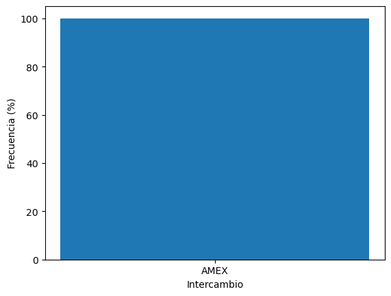

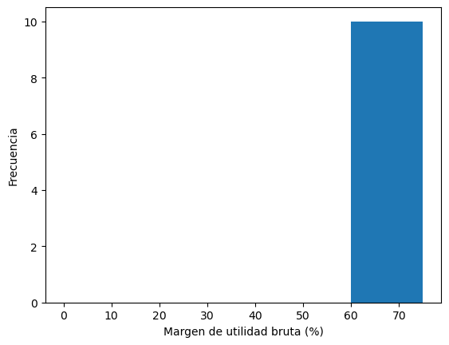

[output not shown]